# Wine Quality Exploration by Laila Alqawain

===================================================

For This project I choosed The Wine Quality Dataset to explore and summarize the data to know what is the most effort on wine quality and which is color of wine that has more turnout, red wine or white wine.

## Introduction

This dataset has 6497 observations and 13 variables. Let’s see the structures of variables.

```
## [1] 6497   13
```

```
## 'data.frame':    6497 obs. of  13 variables:
##  $ alcohol             : num  9.4 9.8 9.8 9.8 9.4 9.4 9.4 10 9.5 10.5 ...
##  $ chlorides           : num  0.076 0.098 0.092 0.075 0.076 0.075 0.069 0.065 0.073 0.071 ...
##  $ citric.acid         : num  0 0 0.04 0.56 0 0 0.06 0 0.02 0.36 ...
##  $ color               : Factor w/ 2 levels "red","white": 1 1 1 1 1 1 1 1 1 1 ...
##  $ density             : num  0.998 0.997 0.997 0.998 0.998 ...
##  $ fixed.acidity       : num  7.4 7.8 7.8 11.2 7.4 7.4 7.9 7.3 7.8 7.5 ...
##  $ free.sulfur.dioxide : num  11 25 15 17 11 13 15 15 9 17 ...
##  $ pH                  : num  3.51 3.2 3.26 3.16 3.51 3.51 3.3 3.39 3.36 3.35 ...
##  $ quality             : int  5 5 5 6 5 5 5 7 7 5 ...
##  $ residual.sugar      : num  1.9 2.6 2.3 1.9 1.9 1.8 1.6 1.2 2 6.1 ...
##  $ sulphates           : num  0.56 0.68 0.65 0.58 0.56 0.56 0.46 0.47 0.57 0.8 ...
##  $ total.sulfur.dioxide: num  34 67 54 60 34 40 59 21 18 102 ...
##  $ volatile.acidity    : num  0.7 0.88 0.76 0.28 0.7 0.66 0.6 0.65 0.58 0.5 ...
```

```
##     alcohol        chlorides        citric.acid       color
##  Min.   : 8.00   Min.   :0.00900   Min.   :0.0000   red  :1599
##  1st Qu.: 9.50   1st Qu.:0.03800   1st Qu.:0.2500   white:4898
##  Median :10.30   Median :0.04700   Median :0.3100
##  Mean   :10.49   Mean   :0.05603   Mean   :0.3186
##  3rd Qu.:11.30   3rd Qu.:0.06500   3rd Qu.:0.3900
##  Max.   :14.90   Max.   :0.61100   Max.   :1.6600
##     density       fixed.acidity    free.sulfur.dioxide       pH
##  Min.   :0.9871   Min.   : 3.800   Min.   :  1.00      Min.   :2.720
##  1st Qu.:0.9923   1st Qu.: 6.400   1st Qu.: 17.00      1st Qu.:3.110
##  Median :0.9949   Median : 7.000   Median : 29.00      Median :3.210
##  Mean   :0.9947   Mean   : 7.215   Mean   : 30.53      Mean   :3.219
##  3rd Qu.:0.9970   3rd Qu.: 7.700   3rd Qu.: 41.00      3rd Qu.:3.320
##  Max.   :1.0390   Max.   :15.900   Max.   :289.00      Max.   :4.010
##     quality      residual.sugar     sulphates      total.sulfur.dioxide
##  Min.   :3.000   Min.   : 0.600   Min.   :0.2200   Min.   :  6.0
##  1st Qu.:5.000   1st Qu.: 1.800   1st Qu.:0.4300   1st Qu.: 77.0
##  Median :6.000   Median : 3.000   Median :0.5100   Median :118.0
##  Mean   :5.818   Mean   : 5.443   Mean   :0.5313   Mean   :115.7
##  3rd Qu.:6.000   3rd Qu.: 8.100   3rd Qu.:0.6000   3rd Qu.:156.0
##  Max.   :9.000   Max.   :65.800   Max.   :2.0000   Max.   :440.0
##  volatile.acidity
##  Min.   :0.0800
##  1st Qu.:0.2300
##  Median :0.2900
##  Mean   :0.3397
##  3rd Qu.:0.4000
##  Max.   :1.5800
```

As we see from structure variables, the type of quality variable is an integer. I will Convert quality datatype into a factor categorical variable.

```
## 'data.frame':    6497 obs. of  13 variables:
##  $ alcohol             : num  9.4 9.8 9.8 9.8 9.4 9.4 9.4 10 9.5 10.5 ...
##  $ chlorides           : num  0.076 0.098 0.092 0.075 0.076 0.075 0.069 0.065 0.073 0.071 ...
##  $ citric.acid         : num  0 0 0.04 0.56 0 0 0.06 0 0.02 0.36 ...
##  $ color               : Factor w/ 2 levels "red","white": 1 1 1 1 1 1 1 1 1 1 ...
##  $ density             : num  0.998 0.997 0.997 0.998 0.998 ...
##  $ fixed.acidity       : num  7.4 7.8 7.8 11.2 7.4 7.4 7.9 7.3 7.8 7.5 ...
##  $ free.sulfur.dioxide : num  11 25 15 17 11 13 15 15 9 17 ...
##  $ pH                  : num  3.51 3.2 3.26 3.16 3.51 3.51 3.3 3.39 3.36 3.35 ...
##  $ quality             : Factor w/ 7 levels "3","4","5","6",..: 3 3 3 4 3 3 3 5 5 3 ...
##  $ residual.sugar      : num  1.9 2.6 2.3 1.9 1.9 1.8 1.6 1.2 2 6.1 ...
##  $ sulphates           : num  0.56 0.68 0.65 0.58 0.56 0.56 0.46 0.47 0.57 0.8 ...
##  $ total.sulfur.dioxide: num  34 67 54 60 34 40 59 21 18 102 ...
##  $ volatile.acidity    : num  0.7 0.88 0.76 0.28 0.7 0.66 0.6 0.65 0.58 0.5 ...
```

As we see after converting, the quality variable has 7 level starting with 3 which is the lowest quality and 9 which is the best quality.

Before creating plots, I will make functions and I will recall the function for every variable to create a plot and print five number summary.

# Univariate Plots Section

In this section, I will perform some preliminary exploration of wine quality dataset. I will describe the variables of the data. Then, I will create univariate plots to understand the structure of the individual variables in wine quality dataset.

Description of attributes:

1 - fixed acidity: most acids involved with wine or fixed or nonvolatile (do not evaporate readily)

2 - volatile acidity: the amount of acetic acid in wine, which at too high of levels can lead to an unpleasant, vinegar taste

3 - citric acid: found in small quantities, citric acid can add ‘freshness’ and flavor to wines

4 - residual sugar: the amount of sugar remaining after fermentation stops, it’s rare to find wines with less than 1 gram/liter and wines with greater than 45 grams/liter are considered sweet

5 - chlorides: the amount of salt in the wine

6 - free sulfur dioxide: the free form of SO2 exists in equilibrium between molecular SO2 (as a dissolved gas) and bisulfite ion; it prevents microbial growth and the oxidation of wine

7 - total sulfur dioxide: amount of free and bound forms of S02; in low concentrations, SO2 is mostly undetectable in wine, but at free SO2 concentrations over 50 ppm, SO2 becomes evident in the nose and taste of wine

8 - density: the density of water is close to that of water depending on the percent alcohol and sugar content

9 - pH: describes how acidic or basic a wine is on a scale from 0 (very acidic) to 14 (very basic); most wines are between 3-4 on the pH scale

10 - sulphates: a wine additive which can contribute to sulfur dioxide gas (S02) levels, wich acts as an antimicrobial and antioxidant

11 - alcohol: the percent alcohol content of the wine

Output variable (based on sensory data): 12 - quality (score between 0 and 10)

As we mansion above, wine dataset contains 11 numerical variables and 2 categorical variables (quality and color).

## Color

```
##   red white
##  1599  4898
```

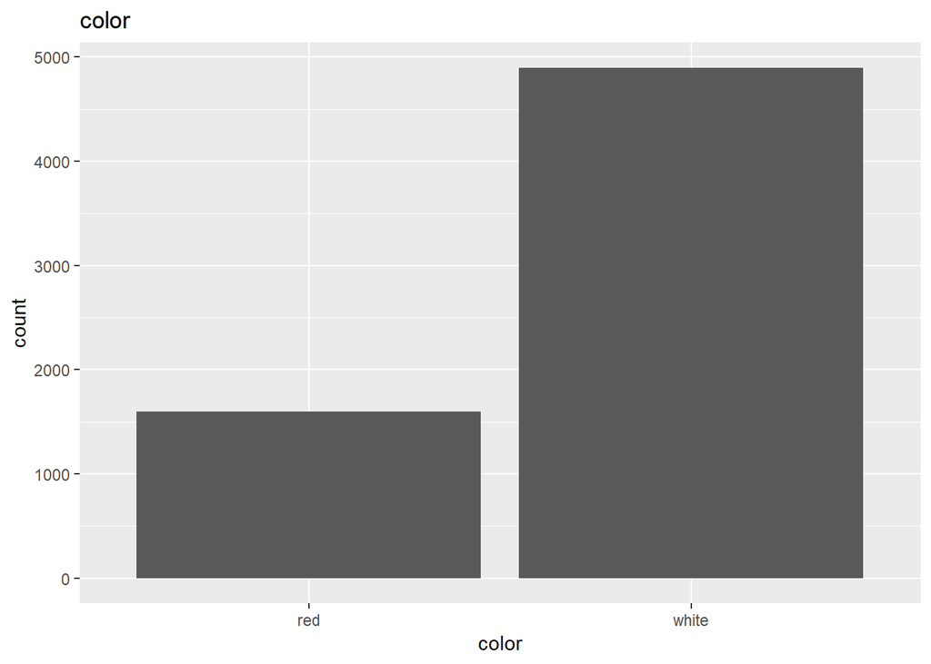

From the bar plot above, we can see that the white wine is higher than the red wine. The wine quality dataset contains 4898 observations about white wine and 1599 observations about red wine.

## Quality

```
##    3    4    5    6    7    8    9
##   30  216 2138 2836 1079  193    5
```

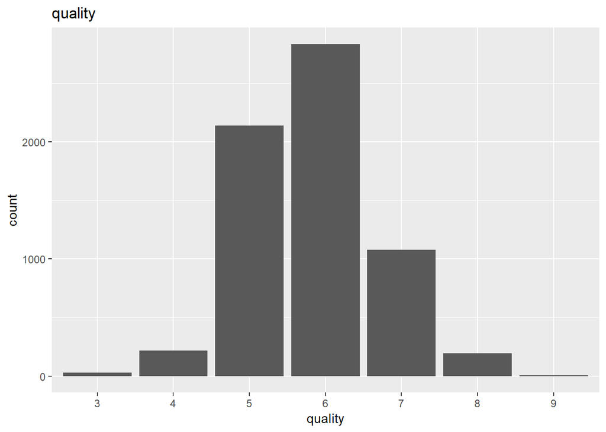

From the bar plot above, we can see that the quality level based on bar plot starting from level 3 to level 9. It looks like a normal distribution, there is one peak which is a level 6 of quality. Level 3 means the wine with the lowest quality and level 9 means the wine with the highest quality. Most of the wine with medium quality which is level 6.

## Alcohol

```
##    Min. 1st Qu.  Median    Mean 3rd Qu.    Max.
##    8.00    9.50   10.30   10.49   11.30   14.90
```

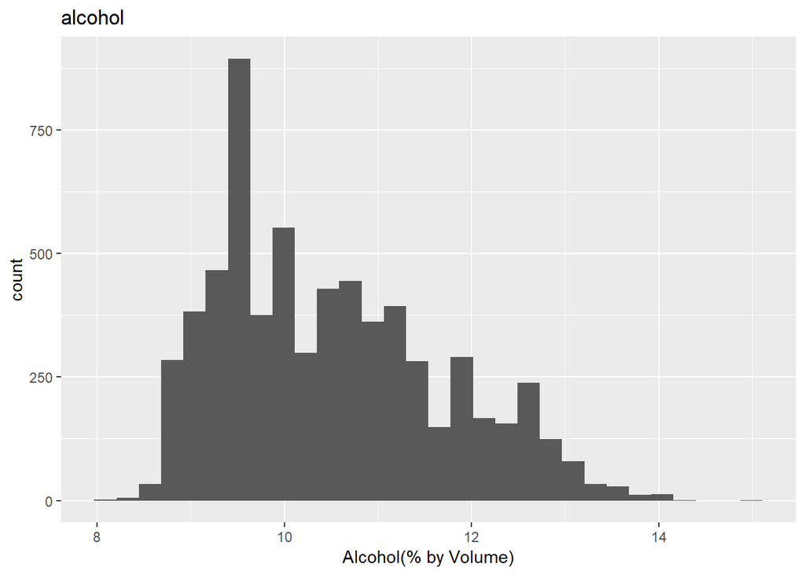

From the histogram above, we can see that the peak percent of alcohol in the wine between 9 and 10. This is the right skewed so, I will choose the median as a measure of center which is 10.30 instead of mean because the mean will be affected from the outliers as we see there is one outlier in 15.

## Chlorides

```
##    Min. 1st Qu.  Median    Mean 3rd Qu.    Max.
## 0.00900 0.03800 0.04700 0.05603 0.06500 0.61100
```

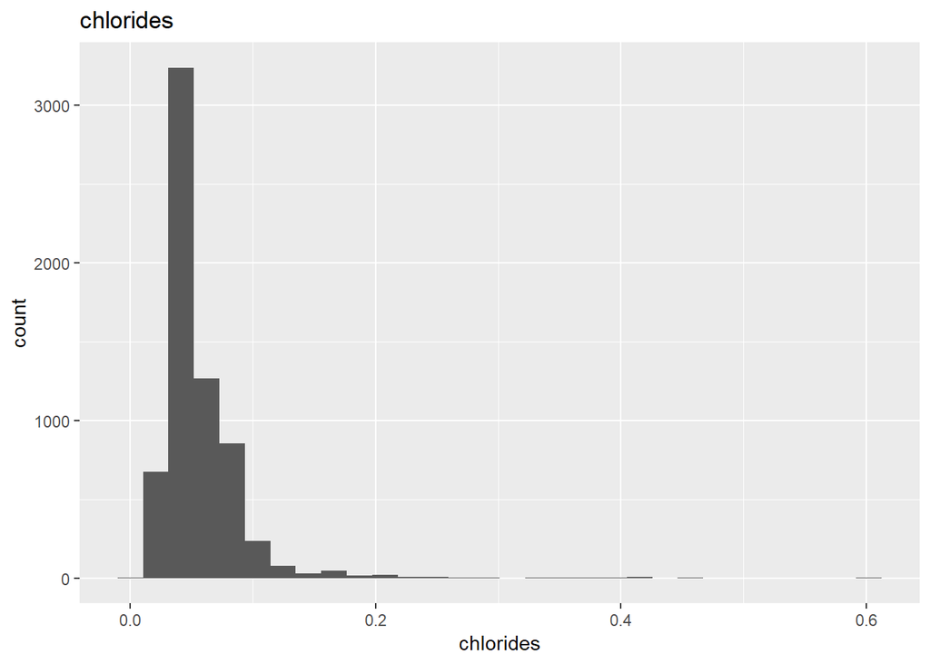

## Density

```
##    Min. 1st Qu.  Median    Mean 3rd Qu.    Max.
##  0.9871  0.9923  0.9949  0.9947  0.9970  1.0390
```

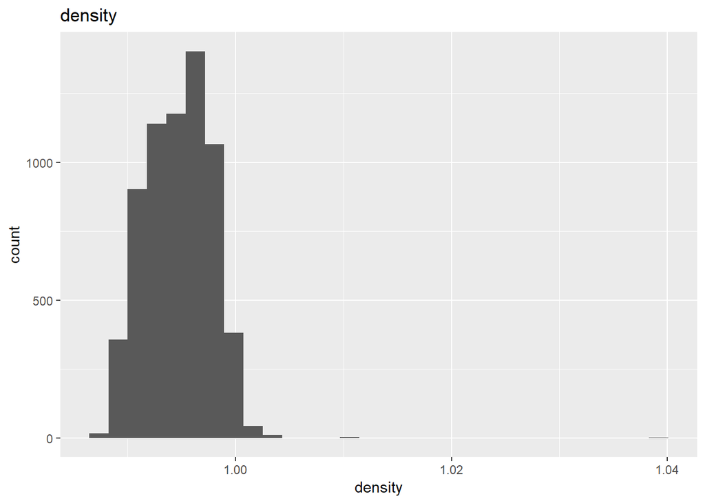

From the histogram above, we can notice there is one peack below 1.00. It is the right skewed so, I will choose the median as a measure of center which is 0.99 instead of mean because the mean will be affected from the outliers as we see there is one outlier in 1.01.

## Citric Acid

```
##    Min. 1st Qu.  Median    Mean 3rd Qu.    Max.
##  0.0000  0.2500  0.3100  0.3186  0.3900  1.6600
```

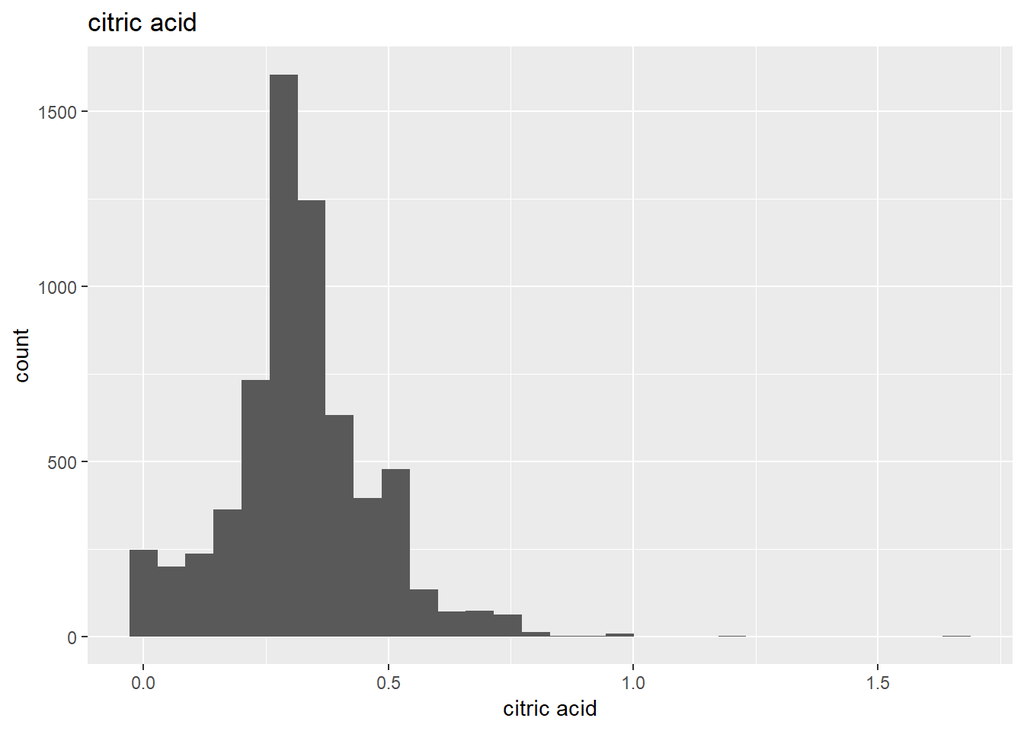

From the histogram above, we can notice there is one peack. It is the right skewed so, I will choose the median as a measure of center which is 0.31 instead of mean because the mean will be affected from the outliers as we see there is one outlier in 1.66 which is the max and didn’t appear on the histogram.

## Fixed Acidity

```
##    Min. 1st Qu.  Median    Mean 3rd Qu.    Max.
##   3.800   6.400   7.000   7.215   7.700  15.900
```

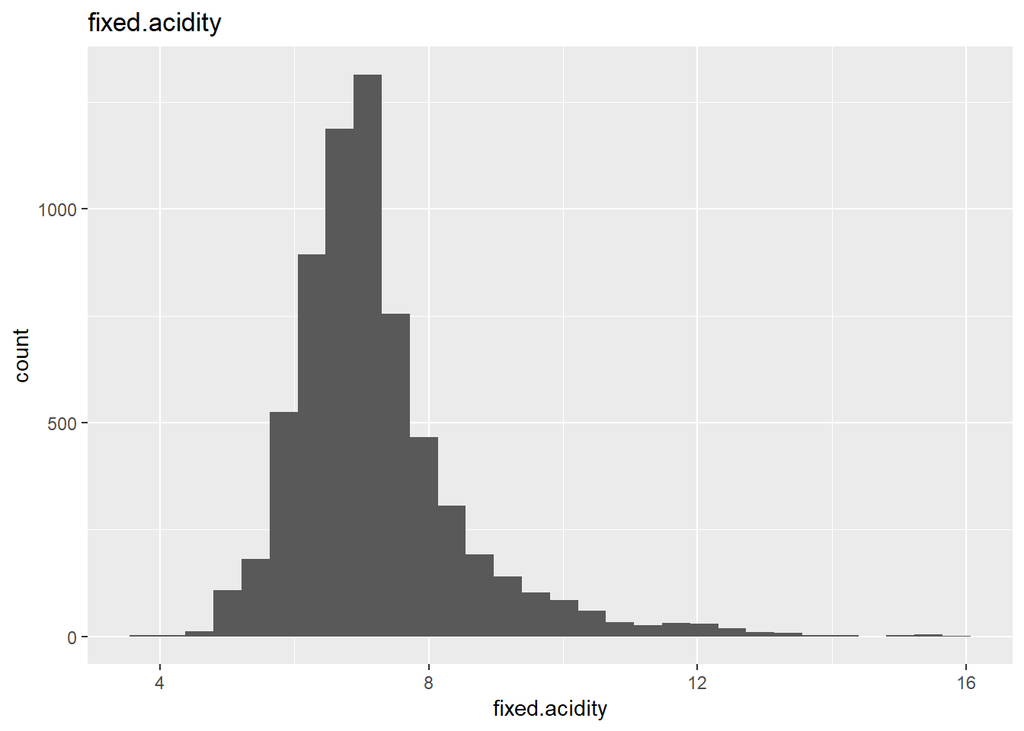

From the histogram above, we can notice there is one peack in 7.3. It is the right skewed so, I will choose the median as a measure of center which is 7.0 instead of mean because the mean will be affected from the outliers as we see there is one outlier in 15.9.

## Free Sulfur Dioxide

```
##    Min. 1st Qu.  Median    Mean 3rd Qu.    Max.
##    1.00   17.00   29.00   30.53   41.00  289.00
```

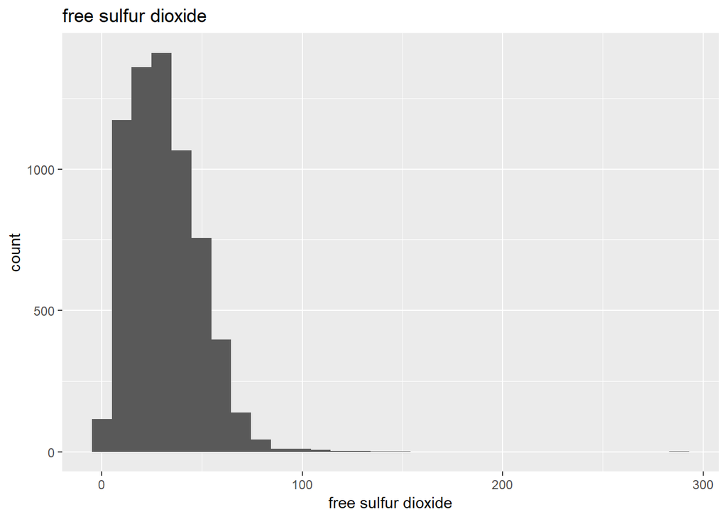

From the histogram above, we can notice there is one peack. It is the right skewed so, I will choose the median as a measure of center which is 29.0 instead of mean because the mean will be affected from the outliers as we see there is one outlier which is the max 289.0 but we can’t see it on the histogram.

## pH

```
##    Min. 1st Qu.  Median    Mean 3rd Qu.    Max.
##   2.720   3.110   3.210   3.219   3.320   4.010
```

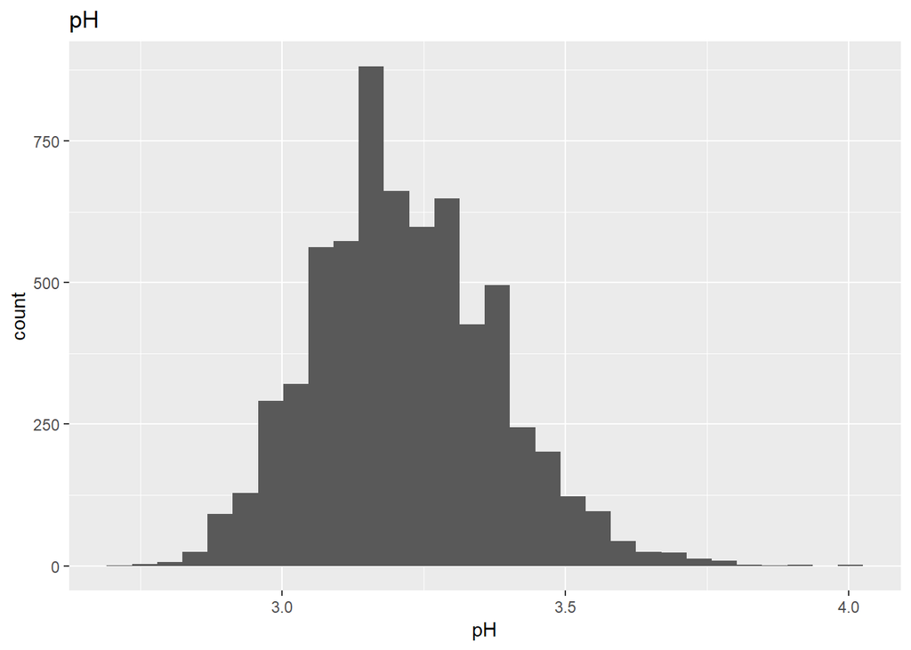

From the histogram above, we can notice that the ph of wine looks like a normal distribution. But actually it is right skewed because there is an outlier in 4.0. The most ph in wine is between 3 and 3.5. From the description of ph variable, pH describes how acidic or basic a wine is on a scale from 0 (very acidic) to 14 (very basic), most wines are between 3-4 on the pH scale. The median is 3.21.

## Residual Sugar

```
##    Min. 1st Qu.  Median    Mean 3rd Qu.    Max.
##   0.600   1.800   3.000   5.443   8.100  65.800
```

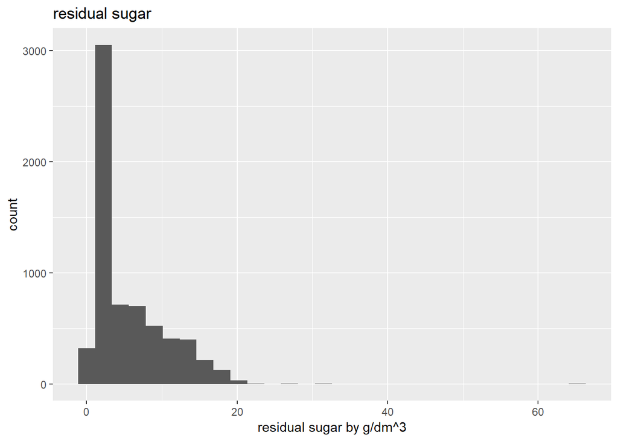

From the histogram above, we can notice there is one peack. It is the right skewed so, I will choose the median as a measure of center which is 3.00 instead of mean because the mean will be affected from the outliers as we see there is one outlier which is the max 65.80 but we can’t see it on the histogram.

## Sulphates

```
##    Min. 1st Qu.  Median    Mean 3rd Qu.    Max.
##  0.2200  0.4300  0.5100  0.5313  0.6000  2.0000
```

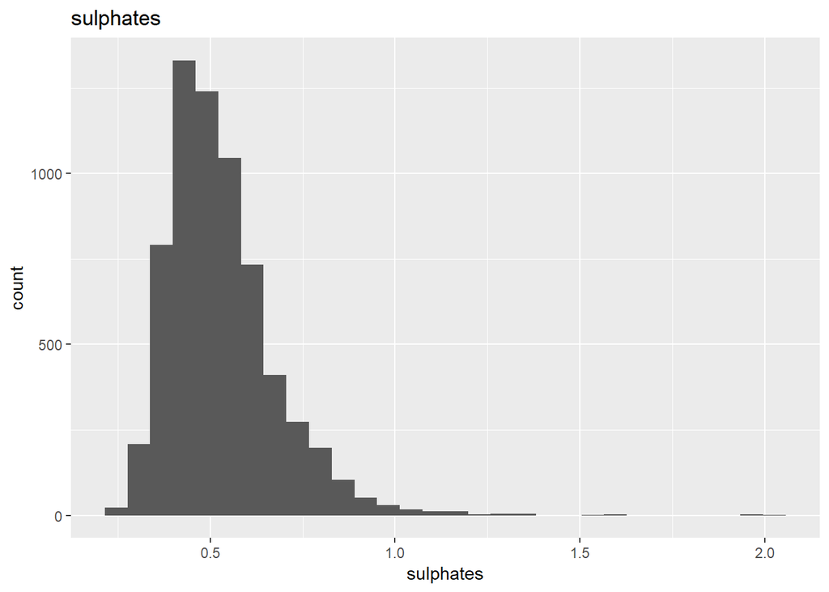

From the histogram above, we can notice there is one peack in 0.4. It is the right skewed so, I will choose the median as a measure of center which is 0.51 instead of mean because the mean will be affected from the outliers as we see there are two outliers between 1.5 and 2.0.

## Total Sulfur Dioxide

```
##    Min. 1st Qu.  Median    Mean 3rd Qu.    Max.
##     6.0    77.0   118.0   115.7   156.0   440.0
```

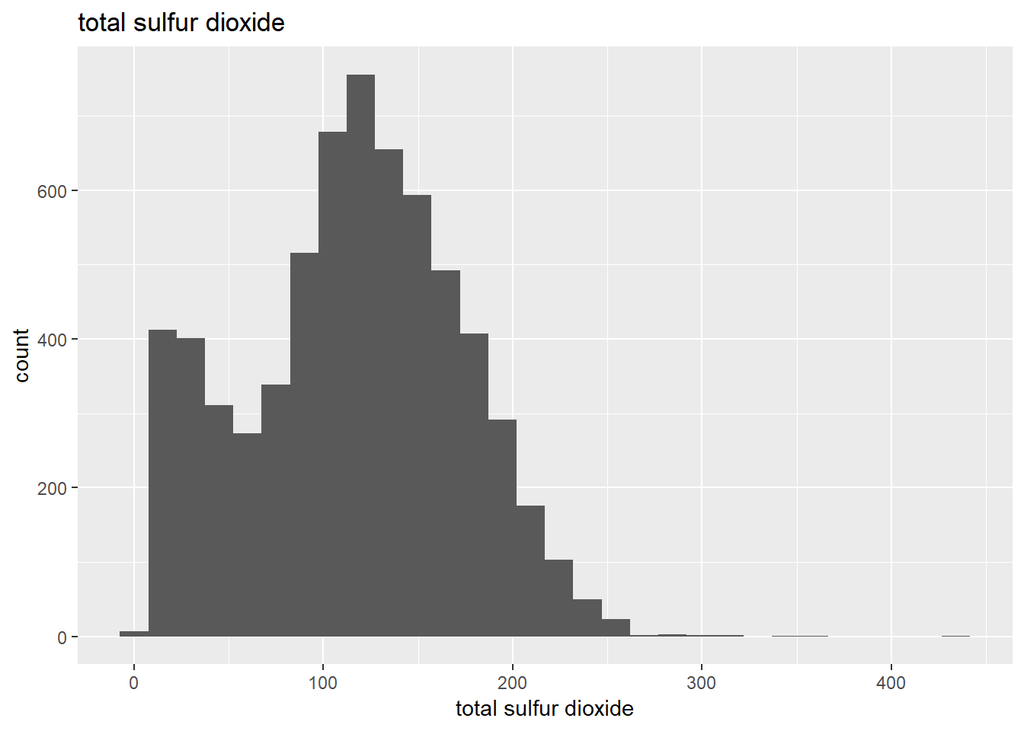

## Volatile Acidity

```
##    Min. 1st Qu.  Median    Mean 3rd Qu.    Max.
##  0.0800  0.2300  0.2900  0.3397  0.4000  1.5800
```

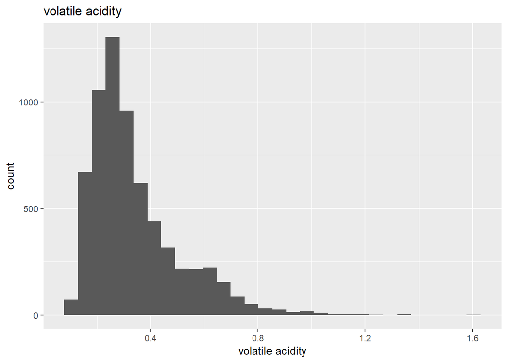

From the histogram above, we can notice there is one peack in 0.2. It is the right skewed so, I will choose the median as a measure of center which is 0.29 instead of mean because the mean will be affected from the outliers as we see there are two outliers in 1.3 and the max which is 1.58 and it didn’t appear on the histogram.

# Univariate Analysis

### What is/are the main feature(s) of interest in your dataset?

There are two features that I interested in Wine Quality dataset which are Color and Quality.

### What other features in the dataset do you think will help support your investigation into your feature(s) of interest?

They are Alcohol, Chlorides, pH, density, total sulfur dioxide, and residual sugar. I will explore the dataset to find the distribution and the relationships between these variables and how they affect the quality and find the difference between each color of the wine based on these variables.

### Did you create any new variables from existing variables in the dataset?

No, I did not.

### Of the features you investigated, were there any unusual distributions? Did you perform any operations on the data to tidy, adjust, or change the form of the data? If so, why did you do this?

# Bivariate Plots Section

In this section, I will look forward to the relationships between the main output features and supporting variables Also, the relationships between the supporting variables together. I will make sub data from the wine dataset with 1000 sample and I’ll choose the specific features that I would like to explore the relationships among them.

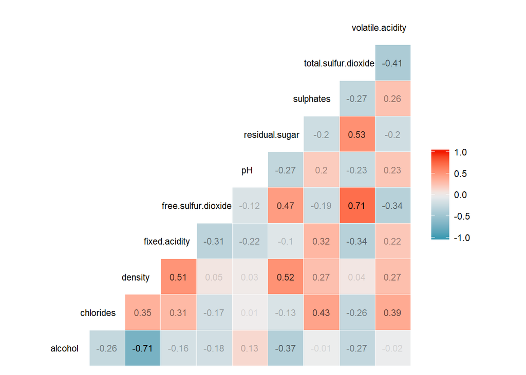

From pairs plot above, I can see the relationships and the correlations, the most are weak, a few are moderate and strong relationships. As we see the dark red means the strong relationship. Let’s see by closer each relationship separately.

## Quality vs. (pH, Alcohol, Chlorides, Density)

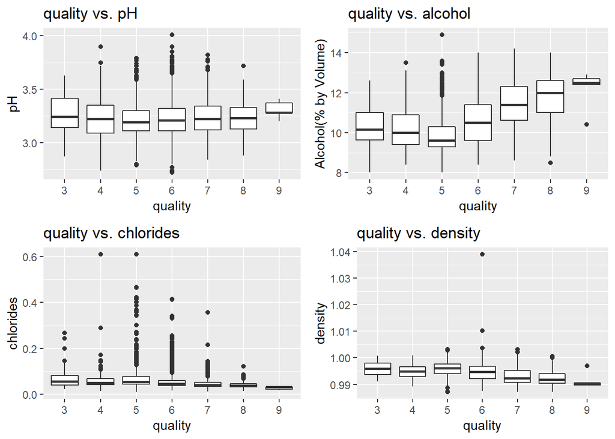

From box plots above, I notice the weak negative relationship between quality with chlorides and density. Also, the weak positive relationship with pH. The moderate positive relationship with alcohol. Let’s compute the r correlation to confirm that. ?cor.test

```
## starting httpd help server ... done
```

```
## [[1]]
##
##  Spearman's rank correlation rho
##
## data:  rank(wine$quality) and rank(wine$pH)
## S = 4.422e+10, p-value = 0.00872
## alternative hypothesis: true rho is not equal to 0
## sample estimates:
##        rho
## 0.03253772
##
##
## [[2]]
##
##  Spearman's rank correlation rho
##
## data:  rank(wine$quality) and rank(wine$alcohol)
## S = 2.528e+10, p-value < 2.2e-16
## alternative hypothesis: true rho is not equal to 0
## sample estimates:
##       rho
## 0.4469255
##
##
## [[3]]
##
##  Spearman's rank correlation rho
##
## data:  rank(wine$quality) and rank(wine$chlorides)
## S = 5.9194e+10, p-value < 2.2e-16
## alternative hypothesis: true rho is not equal to 0
## sample estimates:
##        rho
## -0.2950542
##
##
## [[4]]
##
##  Spearman's rank correlation rho
##
## data:  rank(wine$quality) and rank(wine$density)
## S = 6.0462e+10, p-value < 2.2e-16
## alternative hypothesis: true rho is not equal to 0
## sample estimates:
##       rho
## -0.322806
```

As we said before, the weak positive relationship (quality ~ pH) = 0.03. The moderate positive relationship (quality ~ alcohol) = 0.44 The weak negative relationship (quality ~ chlorides) = -0.29 The weak ntgative relationship (quality ~ density) = -0.32

## Color vs. pH

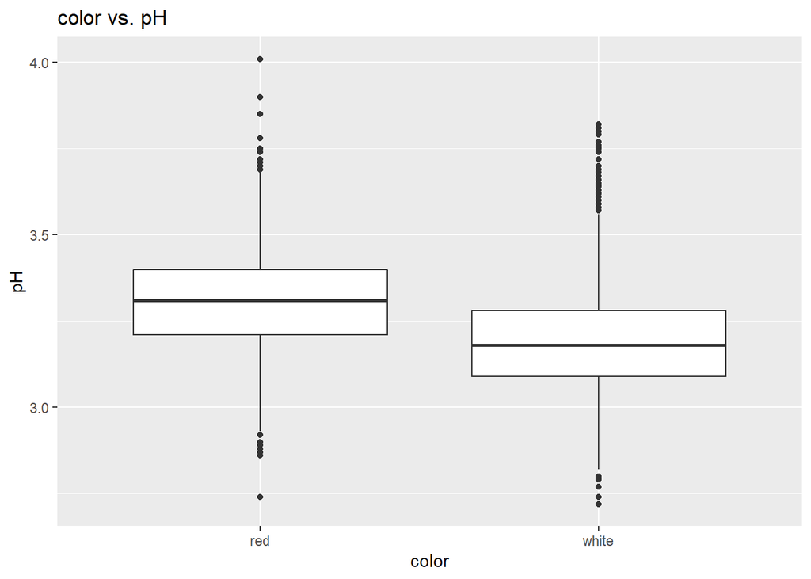

```
## [1] -0.3365062
```

As we see from the boxplot above, we notice that the red wine is higher than white wine in pH. There are outliers in both colors and the correlation value is -0.33 and it means weak negative relationship among them.

## Color vs. Alcohol

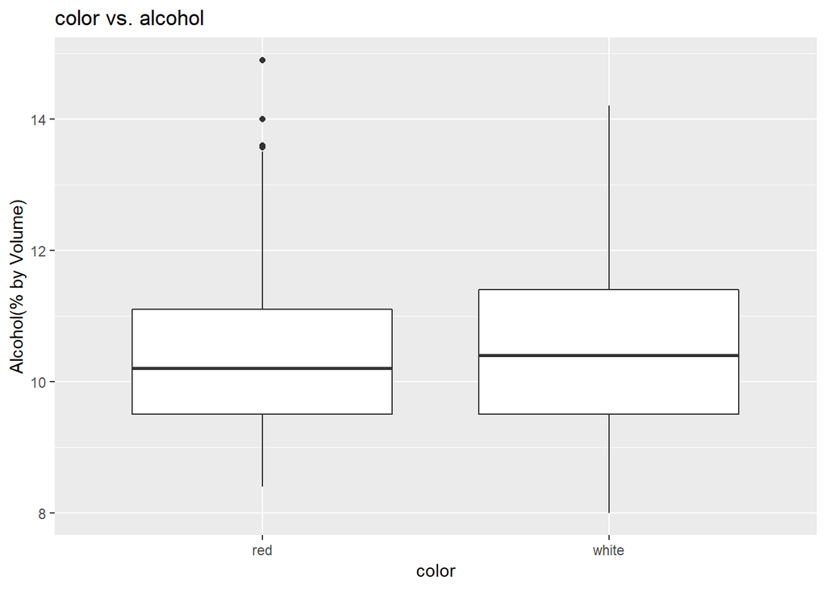

```
## [1] 0.01656501
```

As we see from the boxplot above, we notice that the white wine is a little higher than red wine in alcohol percentage. There are outliers in red wine color and the correlation value is 0.01 and it means the relationship is almost non-existent.

## Color vs. Chlorides

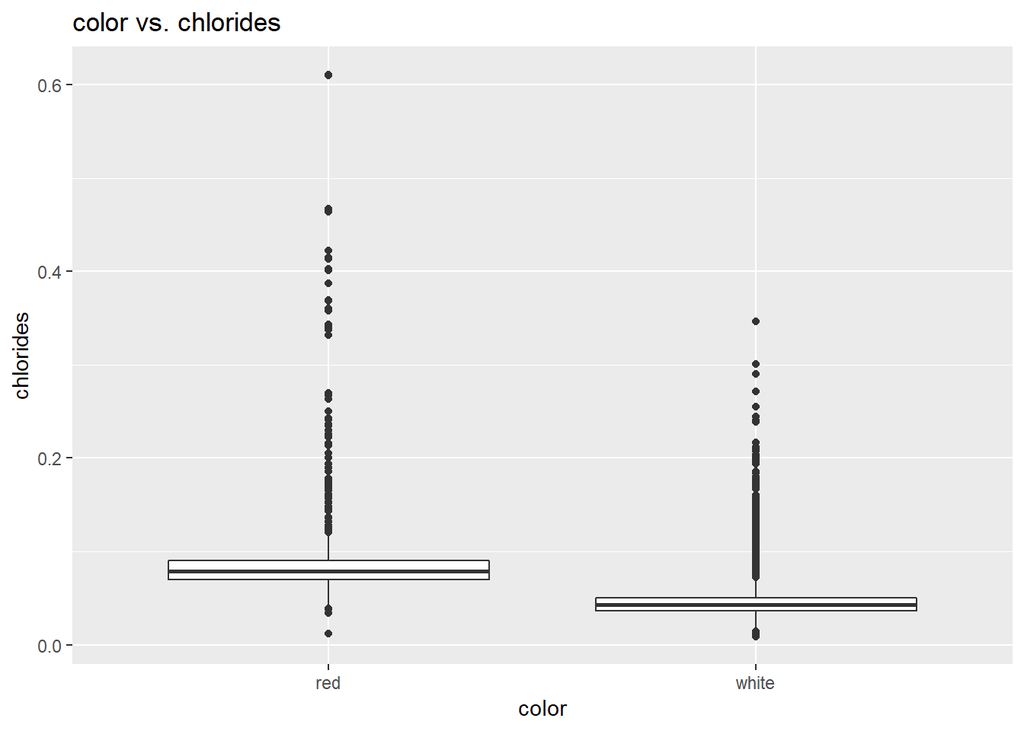

```
## [1] -0.6652526
```

We can notice that the red wine is higher than white wine in percent of chlorides. There are outliers in both of them. The correlation is -0.66 and that means the strong negative relationship among them.

## Color vs. Density

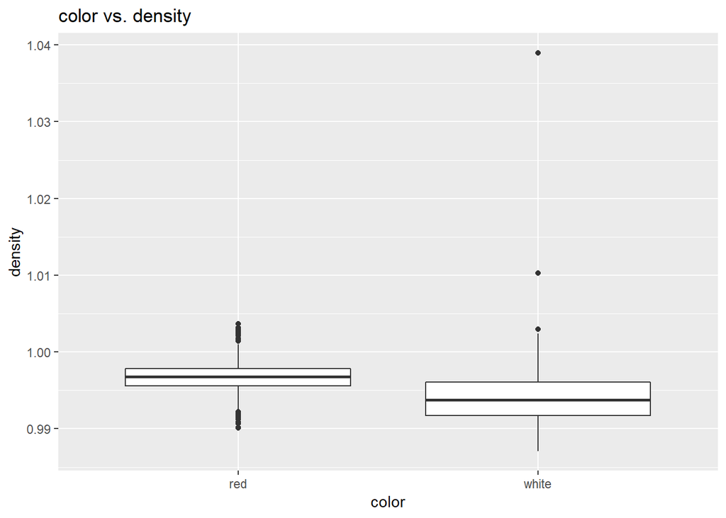

```
## [1] -0.4083559
```

We can notice that the red wine is higher than white wine in density. There are 3 outliers values in white wine. The correlation is -0.408 and that means there is moderate negative relationship.

## PH vs.Alcohol

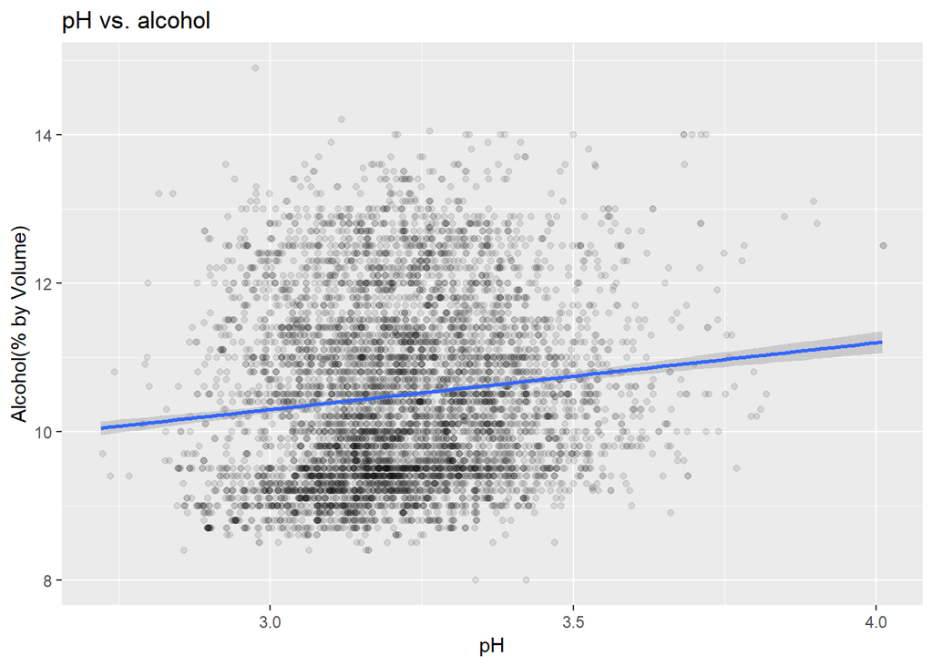

```
## [1] 0.1212485
```

From scatter plot above, We can notice that is weak positive relationship between pH and alcohol. The correlation is 0.12 and that confirms what we see.

## Alcohol vs. Chlorides

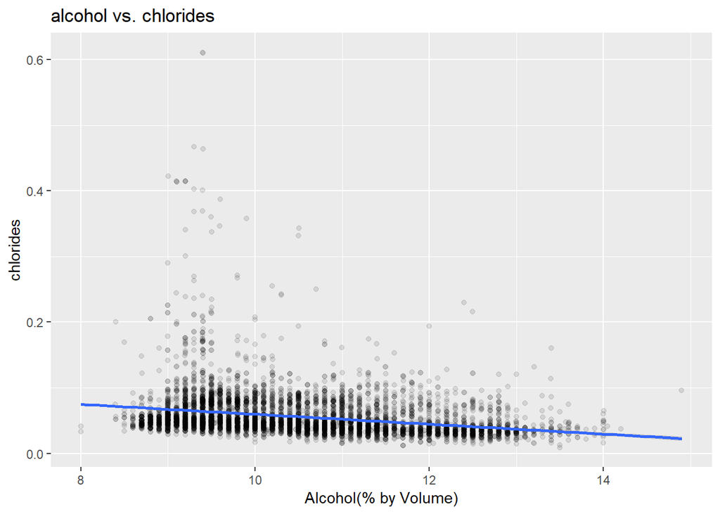

```
## [1] -0.2569156
```

From scatter plot above, We can notice that is weak negative relationship between alcohol and chlorides. The correlation is -0.25 and that confirms what we see.

## Chlorides vs. PH

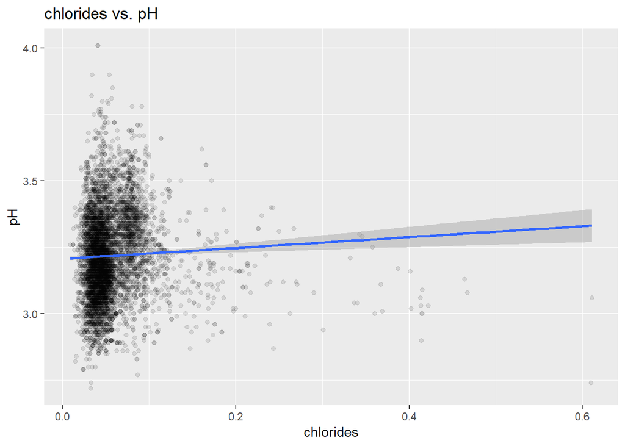

```
## [1] 0.04470798
```

From scatter plot above, We can notice that is very weak positive relationship between chlorides and pH. The correlation is 0.04 and it means the relationship is almost non-existent. This makes sense. so the wine contains the equaled percent of ph and chlorides.

## Density vs. Alcohol

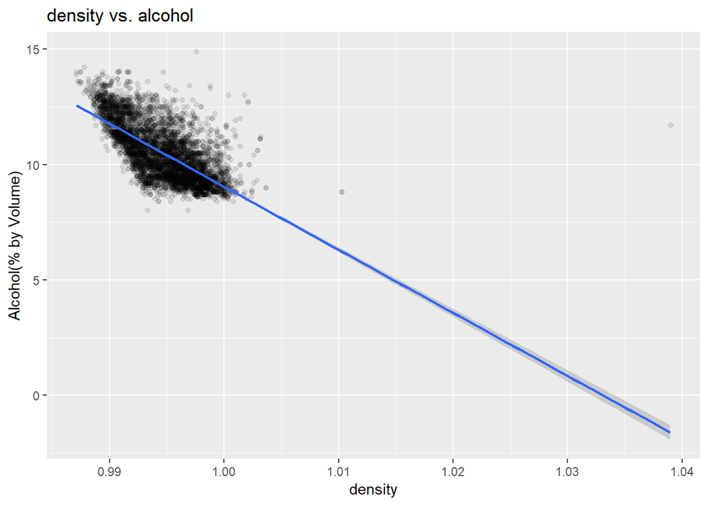

```
## [1] -0.6867454
```

## Total Sulfur Dioxide vs. Residual Sugar

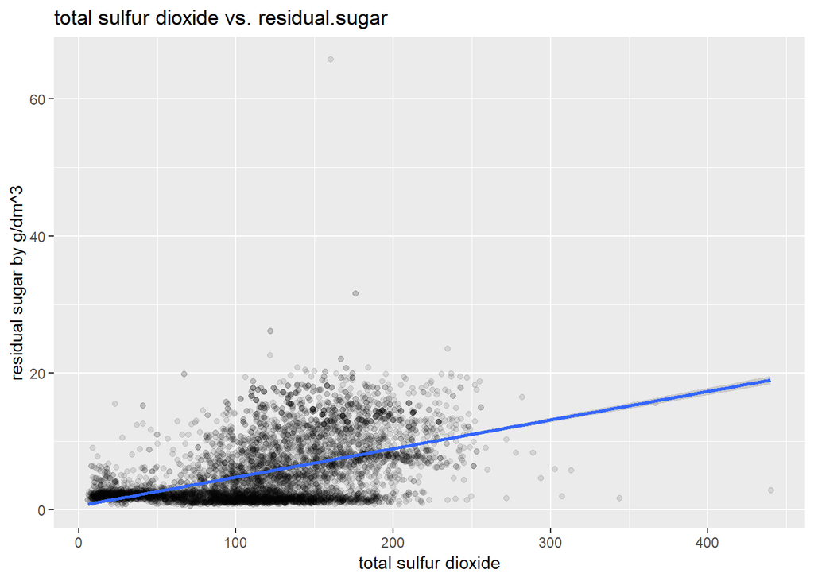

```
## [1] 0.4954816
```

## Residual Sugar vs. Density

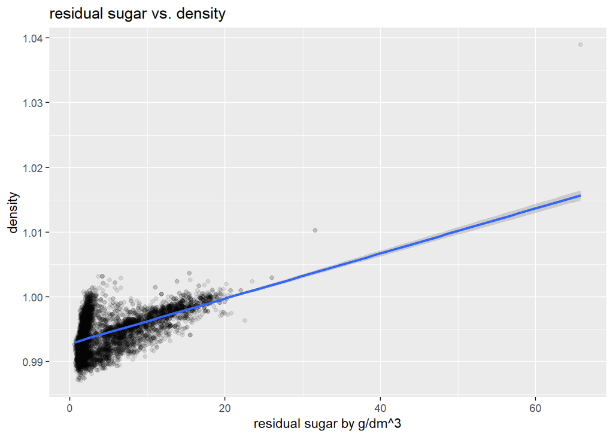

```
## [1] 0.552517
```

From scatter plot above, We can notice that is moderate positive relationship between residual sugar and density. The correlation is 0.55 and that confirms what we see.

## Total Sulfur Dioxide vs. Free Sulfur Dioxide

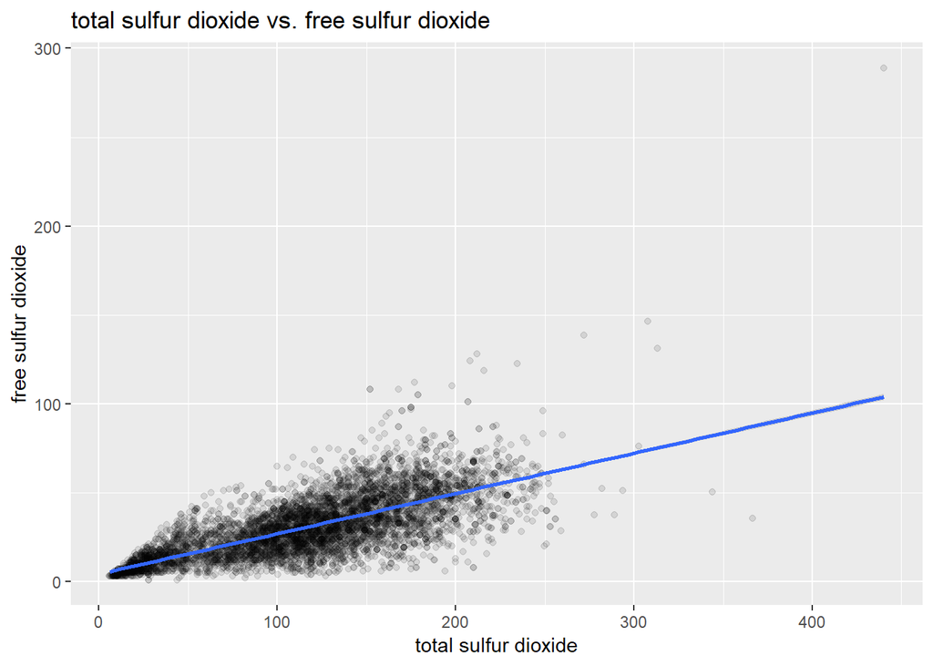

```
## [1] 0.7209341
```

From scatter plot above, We can notice that is strong positive relationship between total sulfur dioxide and free sulfur dioxide. The correlation is 0.72 and that confirms what we see.

## Total Sulfur Dioxide vs. Volatile Acidity

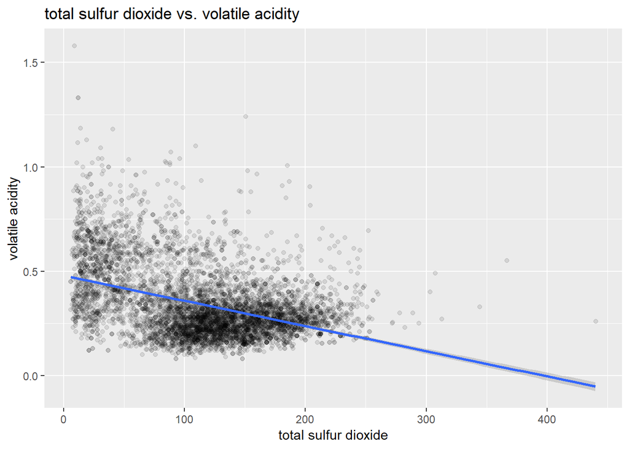

```
## [1] -0.4144762
```

From scatter plot above, We can notice that is moderate negative relationship between total sulfur dioxide and volatile acidity. The correlation is -0.41 and that confirms what we see.

# Bivariate Analysis

### Did you observe any interesting relationships between the other features (not the main feature(s) of interest)?

Yes, I did. I found the strong relationship between two features that i didn’t expect. Total sulfur dioxide correlated strongly with free sulfur dioxide, the higher total sulfur dioxide cause the higher free sulfur dioxide. It was strong positive relationship and the correlation = 0.72.

### What was the strongest relationship you found?

The relationship between Total sulfur dioxide and free sulfur dioxide was the strongest relationship that I found.

# Multivariate Plots Section

In this section, I would like to explore which color of wine had higher in some variables vs. others variabels. I will do create some dataframes and calculate the mean and the median instead of all values and will be more clear for evaluation.

## Median of PH over Alcohol for each Color

```
## # A tibble: 6 x 5
## # Groups:   alcohol [4]
##   alcohol color mean_ph median_ph     n
##     <dbl> <fct>   <dbl>     <dbl> <int>
## 1     8   white    3.38      3.38     2
## 2     8.4 red      3.01      3.01     2
## 3     8.4 white    3.13      3.16     3
## 4     8.5 red      3.15      3.15     1
## 5     8.5 white    3.18      3.19     9
## 6     8.6 white    3.11      3.08    23
```

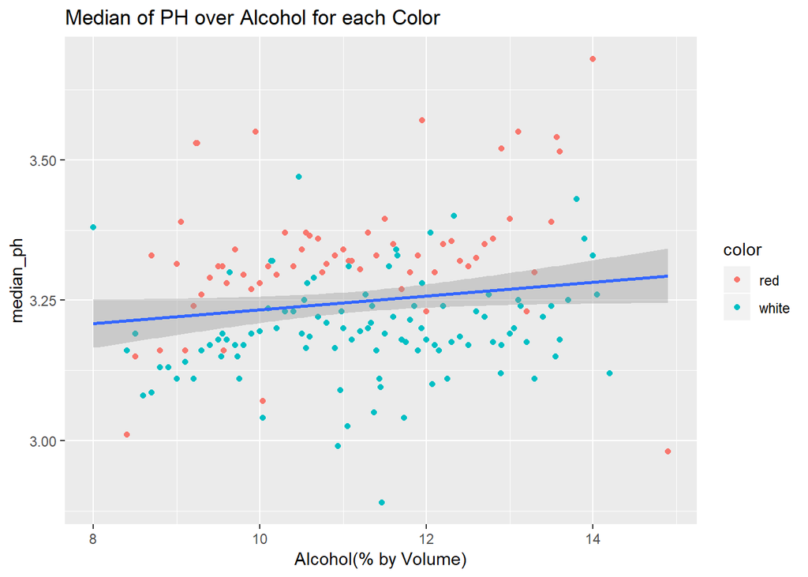

## Median of Chlorides over Alcohol for each Color

```
## # A tibble: 6 x 5
## # Groups:   alcohol [4]
##   alcohol color mean_chlorides median_chlorides     n
##     <dbl> <fct>          <dbl>            <dbl> <int>
## 1     8   white         0.037             0.037     2
## 2     8.4 red           0.138             0.138     2
## 3     8.4 white         0.0533            0.052     3
## 4     8.5 red           0.169             0.169     1
## 5     8.5 white         0.052             0.054     9
## 6     8.6 white         0.0507            0.046    23
```

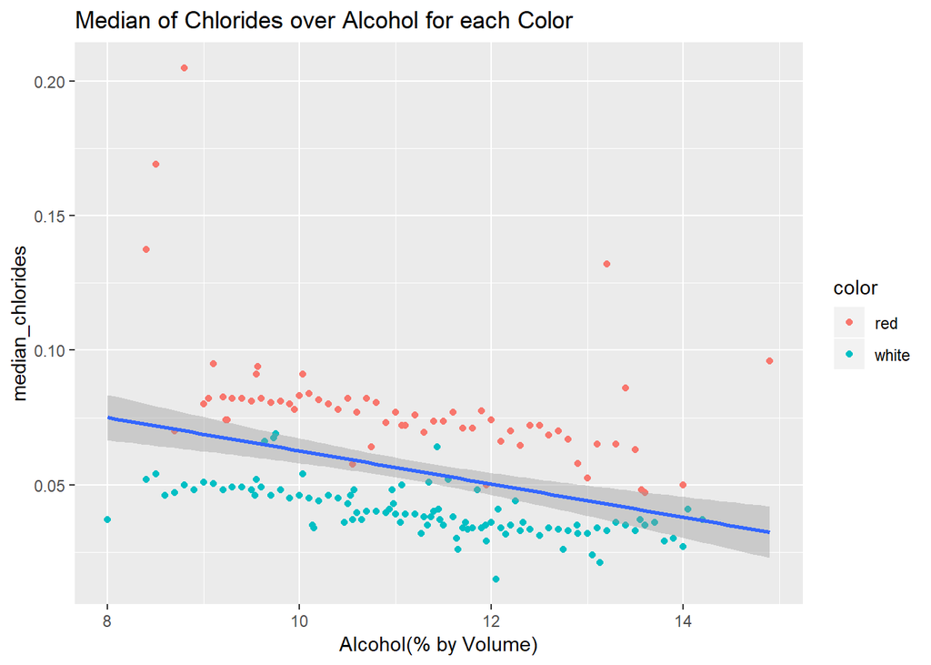

As we see from the scatter plot, the relationship is weakly negative as we saw in the previous section. There is a rise between the red wine and the white wine in alcohol and the median of chlorides, there is one peak for red wine.

## Median of Total Sulfur Dioxide over Free Sulfur Dioxide for each Color

```
## # A tibble: 6 x 5
## # Groups:   free.sulfur.dioxide [4]
##   free.sulfur.dioxi~ color mean_total_sulfur_d~ median_total_sulfur_~     n
##                <dbl> <fct>                <dbl>                 <dbl> <int>
## 1                  1 red                   33.3                    28     3
## 2                  2 red                   45                      45     1
## 3                  2 white                 82                      82     1
## 4                  3 red                   11.1                    10    49
## 5                  3 white                 54.7                    53    10
## 6                  4 red                   12.9                    11    41
```

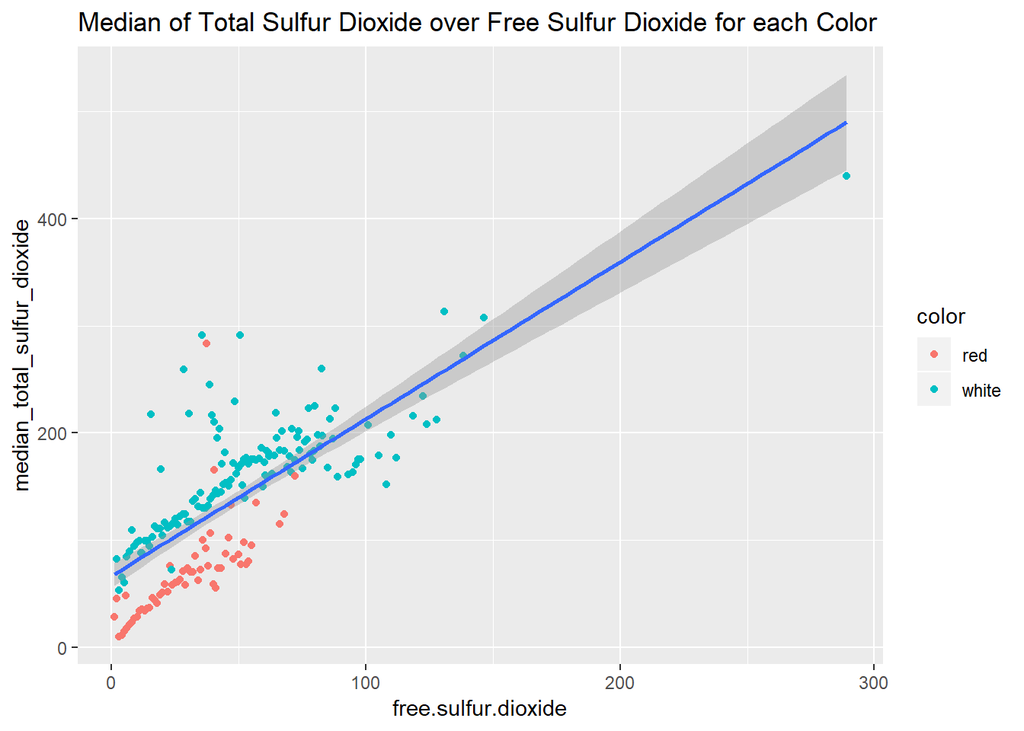

As we see from the scatter plot, The relationship is very strongly positive and that confirms what we saw before. A rise for the white wine on red wine in free sulfur dioxide vs. the median of total sulfur dioxide. They meet in the same peak approximately. The white wine continuous to rise, but the red wine line stopped. I think that based on the dataset that has more information about white wine.

## Median of Density over Quality for each Color

```
## # A tibble: 6 x 5
## # Groups:   quality [3]
##   quality color mean_density median_density     n
##   <fct>   <fct>        <dbl>          <dbl> <int>
## 1 3       red          0.997          0.998    10
## 2 3       white        0.995          0.994    20
## 3 4       red          0.997          0.996    53
## 4 4       white        0.994          0.994   163
## 5 5       red          0.997          0.997   681
## 6 5       white        0.995          0.995  1457
```

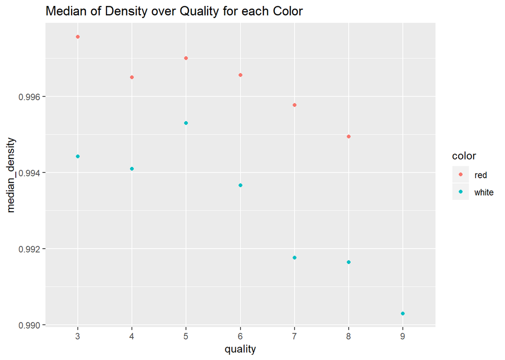

# Multivariate Analysis

### Talk about some of the relationships you observed in this part of the investigation. Were there features that strengthened each other in terms of looking at your feature(s) of interest?

I found the same relationship between the featuer that I explored in the perviouse section, but here I can confirm which color of wine is higher that another one. I found the red wine is higher than the white wine except in this relationship (Median of Total Sulfur Dioxide vs. Free Sulfur Dioxide). So, the remind relationships such as (Median of Chlorides vs. Alcohol, Median of Chlorides vs. Alcohol and Median of Density vs. Quality ) the red wine was higher than the white wine.

### Were there any interesting or surprising interactions between features?

Yes, there were. Although of the red wine observations are very lower than white wine observations only the red wine was significantly higher. One of interested is the relationship between density vs. quality. It was weakly negative relation and the red wine was higher than white wine.

# Final Plots and Summary

### Distribution of Wine Quality

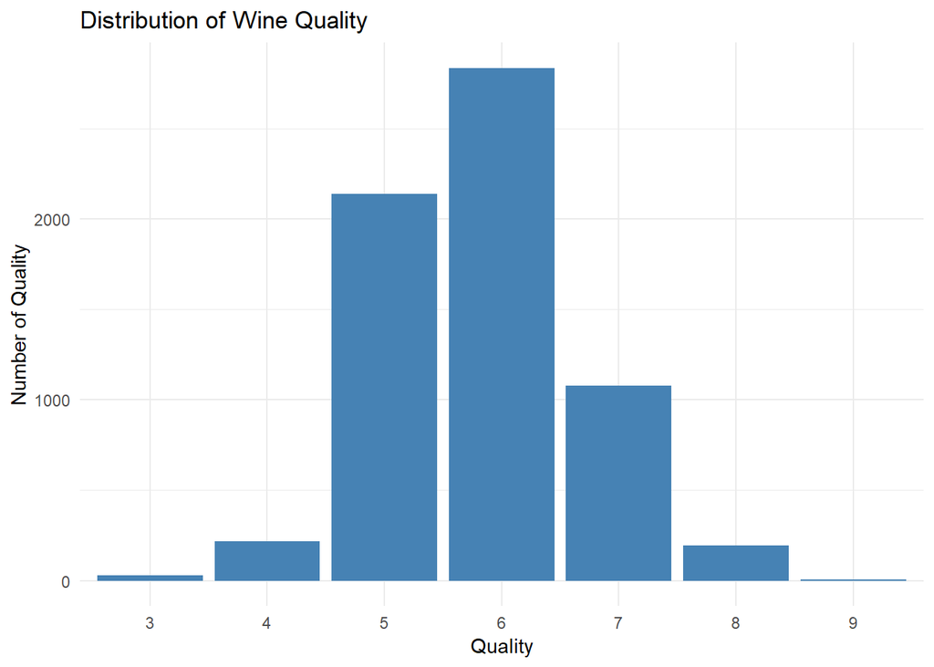

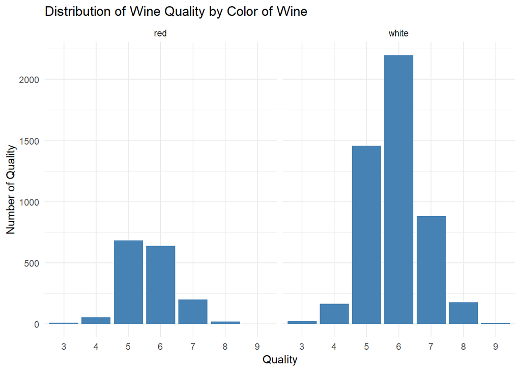

### Description One

The level of quality from 0 to 10, based on wine dataset the minimum level is 3 (low quality) and the maximum level is 9 (high quality). based on bar plot above, we can see the most wines were ranked as 6 then 5. It looks like a normal distribution. Based on Distribution of Wine Quality bar plots, we notice the peak of white wine is 6(medium quality), but the peak of red wine is 5(medium quality). They look like the same quality, I think the highest which we see in white wine is due to the number of observations about white wine. The dataset has 4898 observations about whit wine and just 1599 observations about red wine.

### Alcohol vs. pH

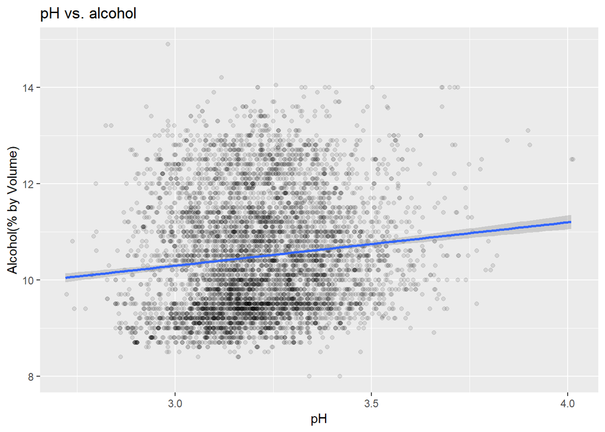

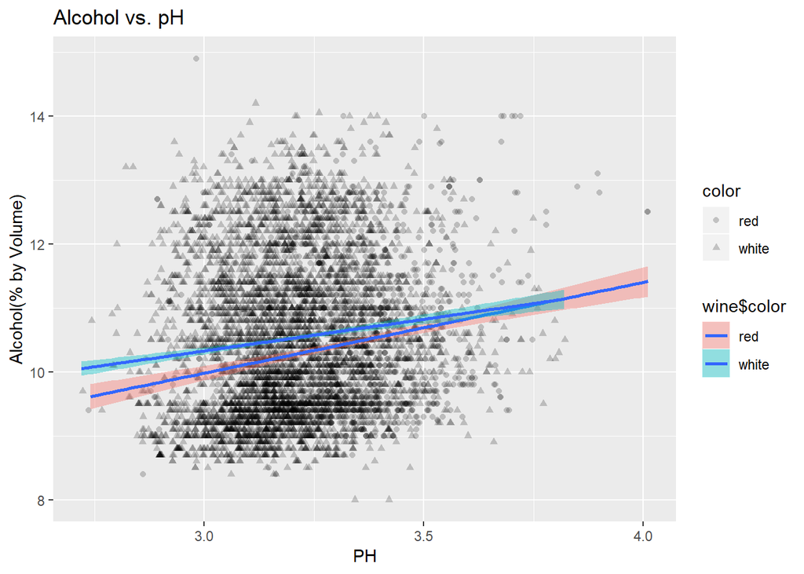

### Median of Chlorides over Alcohol for each Color

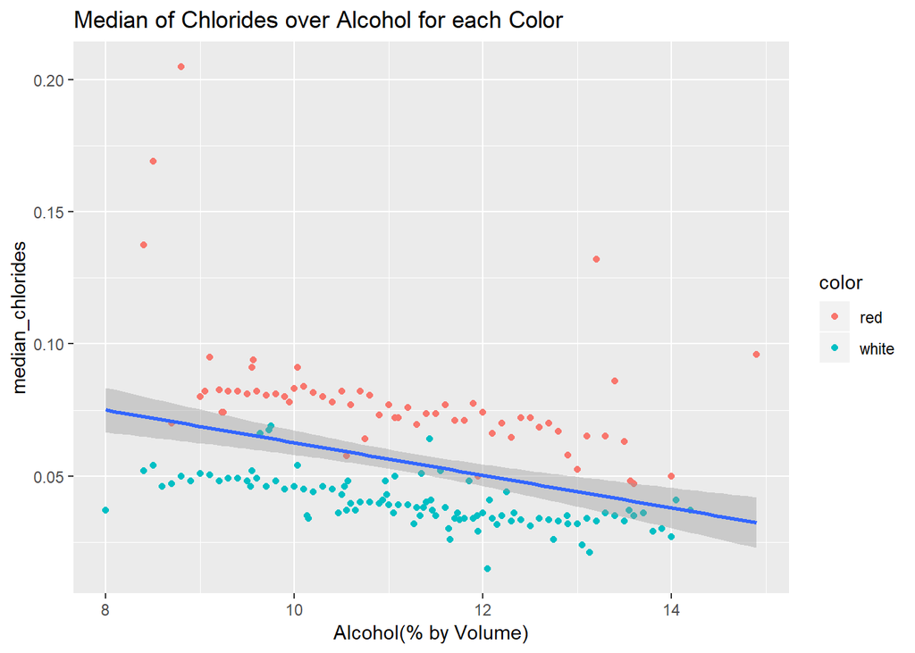

### Description Three

# Reflection

The wine quality dataset contains 6497 observations and 13 variables two of them categorical variables(quality and color). I explored the dataset to find the distribution and the relationships between these variables and how they affect the quality and find the difference between each color of the wine based on these variables.

I found all shapes of distributions were right skewed for all variables except the shape of Total Sulfur Dioxide was left-skewed. Choosing this dataset was a challenge for me. I made sub data from the wine dataset with 1000 sample and selected the specific features to explore the relationships among them.

I found the strong relationship between two features that I didn’t expect. Total sulfur dioxide correlated strongly with free sulfur dioxide, the higher total sulfur dioxide cause the higher free sulfur dioxide. It was a strong positive relationship and the correlation = 0.72. The relationship between Total sulfur dioxide and free sulfur dioxide was the strongest relationship that I found.

I created some data frames and calculated the mean and the median instead of all values to be more clear for evaluation which color of wine had higher in some variables vs. others variables. After that, I found the same relationship between the features that I explored in the previous section, but here I can confirm which color of the wine is higher than another one. I found the red wine is higher than the white wine except in this relationship (Median of Total Sulfur Dioxide vs. Free Sulfur Dioxide). So, the remind relationships such as (Median of Chlorides vs. Alcohol, Median of Chlorides vs. Alcohol and Median of Density vs. Quality ) the red wine was higher than the white wine.

Although of the red wine observations are very lower than white wine observations only the red wine was significantly higher. One of interested is the relationship between density vs. quality. It was weakly negative relation and the red wine was higher than white wine.

======================================================

# Resources

- https://stackoverflow.com/questions/46384546/how-to-find-correlation-coefficients-for-non-numeric-variables
- http://www.flutterbys.com.au/stats/tut/tut5.3.html
- https://stats.idre.ucla.edu/r/faq/frequently-asked-questions-about-rhow-can-i-subset-a-data-setthe-r-program-as-a-text-file-for-all-the-code-on-this-page-subsetting-is-a-very-important-component/
- https://www.udemy.com/r-programming/learn/v4/t/lecture/4636948?start=90
- https://www.udemy.com/r-programming/learn/v4/t/lecture/4721378?start=0
- https://support.rstudio.com/hc/en-us/articles/200549016-Customizing-RStudio#editing
- https://briatte.github.io/ggcorr/
- http://www.sthda.com/english/wiki/ggplot2-scatter-plots-quick-start-guide-r-software-and-data-visualization